# Digital Data Capture & Analysis Lab Book

Edward Mason

## Weeks 1 and 2: Creating a 360 Virtual Tour of Campus

This week we have been using [ThingLink](https://thinglink.com) and 360 photos taken with GoPro/Insta360 cameras to create 360 Virtual Tours.

Our tour is of the Y3 building on the University campus. We started in the basement, going “up” the stairs and out of building, moving past the front of the building and back in via another door. We then went back into the basement via the lift, and then finishing in one of the seminar rooms. We used a GoPro Max camera on a tripod, and connected it via Bluetooth to an iPhone with the GoPro Quik app on for remote control of the shutter.

I then uploaded the footage to ThingLink to create the tour. The platform was fairly intuitive to use, but it was a slow and repetitive task to go through each image in turn, changing settings and adding “tags” to enable moving between each image. Furthermore, there were some shots with people in, which were blurred out for privacy reasons. Viewing it with a VR headset was impressive, despite the low resolution of the images.

A virtual tour such as this would be useful for familiarising people with (for example) a campus, office space, or a new development. However, ethical concerns such as photographing of bystanders, as well as taking photos of sensitive sites should be considered.

Below is the final tour on ThingLink.

[interactive chart not shown]

Figure 1: A virtual tour of University of Birmingham Y3 Building

## Weeks 3 and 4: Photogrammetry (Structure for Motion modelling)

[interactive chart not shown]

Figure 2: A model of an IKEA Marius stool

The model above is of an IKEA Marius stool in my living room. Overall, I would say this model is quite poor, as it does not adequately represent the stool.

Firstly, the mesh of the model is quite poor, leading to holes and floating geometry, as ghost points are formed. There was also erroneous mesh points formed from carpet and wall shots. As well as this, the texture of the model is very poorly captured, with none of the black colour of the stool in the model.

Both of these issues could be due to the lack of a plain background (making it more difficult for the software to distinguish what the focus is), a poor photo distribution (i.e. the photos did not provide sufficient coverage of the stool), or possibly poor camera quality. The other point to consider is the software used - an open-source package called [Regard3D](https://regard3d.org). Alternative methods of processing could be considered, such as modifying parameters, however considering the aforementioned background concerns, these would probably be not as consequential in approving the final model output.

## Weeks 5 and 7: Enivronmental Sensing

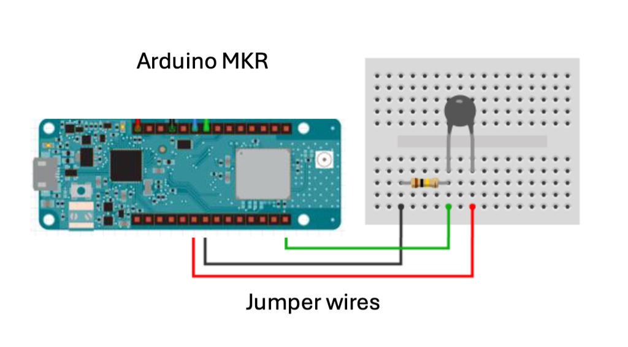

Figure 3: Temperature Sensor Schematic

### Calibration

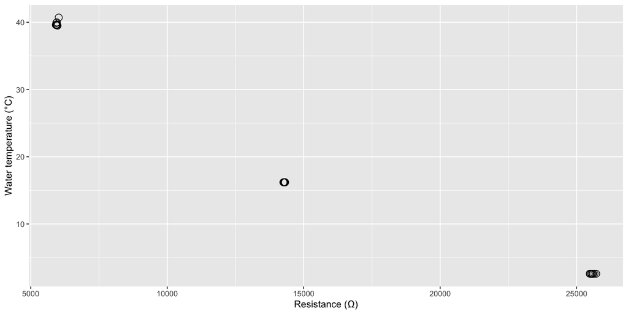

Figure 4: A graph to show Resistance against Temperature as measured by an Arduino-based temperature sensor

We can see a clear pattern of an increase of resistance as temperature decreases - this means that the thermistor used has a negative temperature coefficient (an NTC thermistor).

Next, we will fit a calibration model to the data. The code below creates a linear and non-linear (polynomial) model from the data.

```r
linear_model <- lm(data = df_cal,
                   formula = Ref_temp ~ Resistance)

poly_model <- lm(data = df_cal,
                 formula = Ref_temp ~ poly(
                   x = Resistance, degree = 2, raw = T))
```

The summaries are shown in the table below:

Table 1: Calibration Model Summaries

| Model | Residual Std. Error | Multiple R-Squared | F-Statistic and p-value |
| --- | --- | --- | --- |
| Linear Model | 3.784 (28 *df*) | 0.9434 | 466.4, p < 2.2e-16 |
| Polynomial Model | 0.2554 (27 *df*) | 0.9998 | 5.424 × 10<sup>4</sup> , p < 2.2e-16 |

The summary statistics from this model shows that the polynomial model is a better fit to the data, with a smaller residual standard error, and a larger R-Squared value and F-Statistic.

Below are the models plotted against the data:

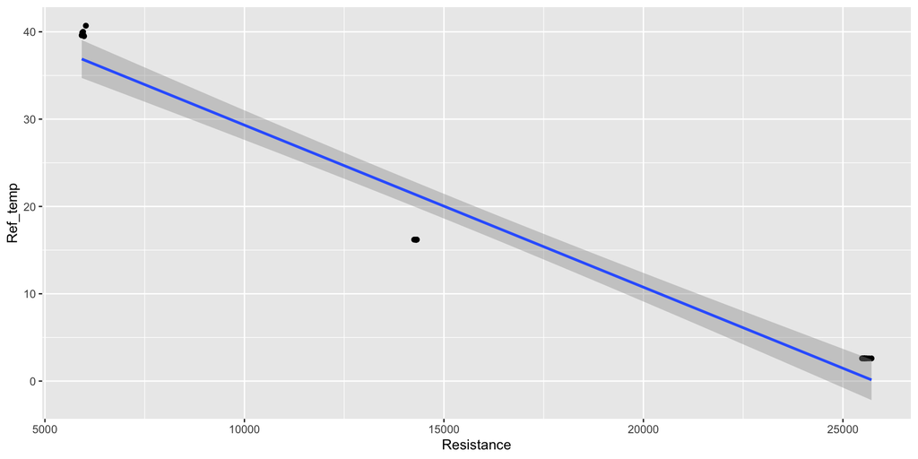

Figure 5: A graph to show Resistance against Temperature with a linear model

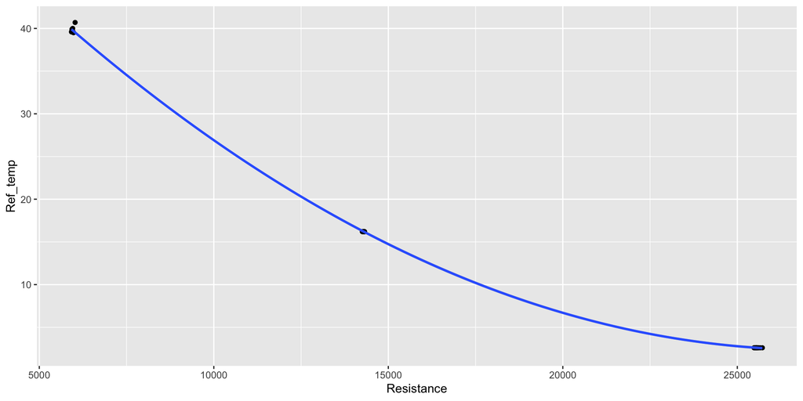

Figure 6: A graph to show Resistance against Temperature with a non-linear model

The mean and standard deviation for each model is shown below.

Table 2: Summary Statistics for each Reference Temperature and Model

| Ref Temp (°C) | Beta Model (Mean ± SD °C) | Linear Model (Mean ± SD °C) | Poly Model (Mean ± SD °C) | Log Linear Model (Mean ± SD °C) |
| --- | --- | --- | --- | --- |
| 2.6 | 5.271±0.056 | 0.415±0.135 | 2.6±0.02 | 2.113±0.073 |
| 16.2 | 17.167±0.031 | 21.34±0.038 | 16.202±0.044 | 17.012±0.037 |
| 39.5 | 37.036 | 36.779 | 39.691 | 39.348 |
| 39.6 | 37.192±0.088 | 36.849±0.04 | 39.825±0.075 | 39.512±0.092 |
| 39.7 | 37.173 | 36.841 | 39.809 | 39.492 |
| 39.9 | 37.219 | 36.862 | 39.848 | 39.54 |
| 40.0 | 37.136 | 36.824 | 39.777 | 39.452 |
| 40.7 | 36.853 | 36.695 | 39.532 | 39.154 |

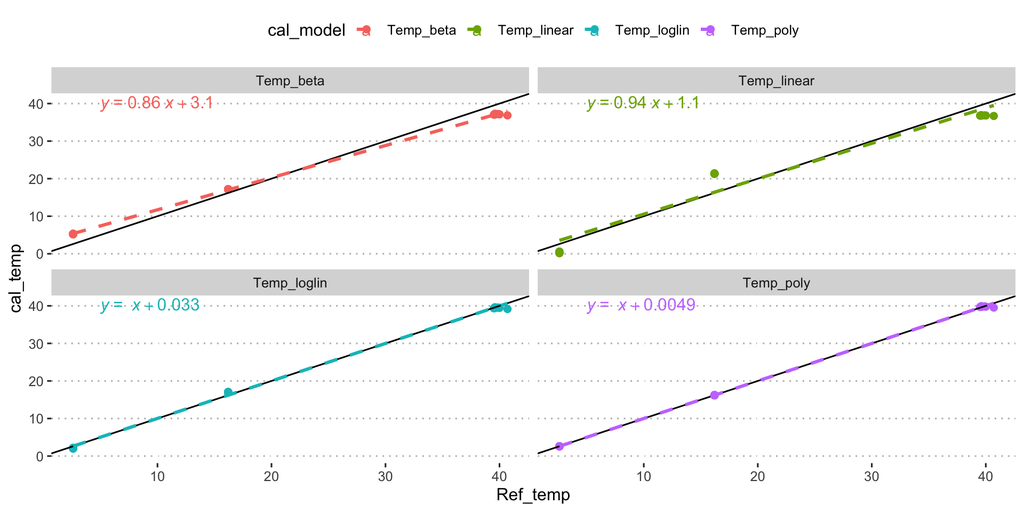

Figure 7: Models Comparison

```r
df_cal_long <- df_cal |> pivot_longer(!c(Cal_medium, Resistance,
                                       Voltage, Ref_temp,
                                       Log_res),
                                    names_to = "cal_model",
                                    values_to = "cal_temp")
beta_model <- ThermistorTemperature(R0 = 10000, T0 = 25, R = df_cal$Resistance, betaTH = 3950)

ggplot(data = df_cal_long,
       mapping = aes(x=Ref_temp, y = cal_temp,
       colour = cal_model))+geom_point(size=2)+
  facet_wrap(~cal_model,scales = "fixed")+
  theme_pubclean()+
  geom_abline(slope = 1)+
  geom_smooth(se = F,method = "lm",linetype = "dashed")+
  stat_regline_equation(label.x=5, label.y=40)
```

```r
summary(beta_model)
summary(linear_model)
summary(poly_model)
summary(log_linear_model)

rmse(df_cal$Ref_temp, df_cal$Temp_beta)
rmse(df_cal$Ref_temp, df_cal$Temp_linear)
rmse(df_cal$Ref_temp, df_cal$Temp_poly)
rmse(df_cal$Ref_temp, df_cal$Temp_loglin)
```

Table 3: Statistical Variables for Each Model

| **Variable** | Beta Model | Linear Model | Poly Model | Log Linear Model |
| --- | --- | --- | --- | --- |
| R<sup>2</sup> | N/A | 0.9434 | 0.9998 | 0.9983 |
| RMSE | 2.253915 | 3.655814 | 0.2423138 | 0.6319984 |
| Slope | 0.86 | 0.94 | 1 | 1 |

Table 3 shows that the sensor is quite accurate in calculating temperature, especially when paired with a polynomial model. Whilst this may not be as accurate as a commercial sensor, it gets incredibly close and for most projects this should be fine.

### Analogue-Digital Conversion (ADC)

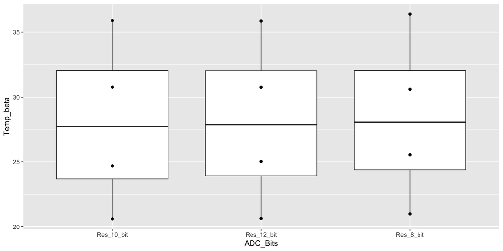

Figure 8: Plot of ADC (using Water reference)

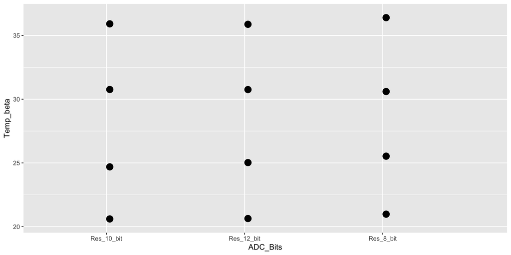

Figure 9: Plot of ADC (Using Water reference, without box)

Table 5: Summary Statistics for each Reference Temperature and Model

| ADC_Bits | Summ_temp_ref |
| --- | --- |
| Res_10_bit | 27.6±6.43 |
| Res_12_bit | 27.6±6.43 |
| Res_8_bit | 27.6±6.43 |
| NA | 27.7±17.819 |

### Todo

The Arduino platform is a well-developed “open-hardware” ecosystem with supporting software and documentation. However, as with all “open-source” systems, there are some pitfalls. Firstly, the system is very much DIY - you are provided with the components, but as the user you must then assemble the parts, both physically (the hardware) and in terms of programming the assembled system to do what you would like it to. This requires, in the case of the Arduino ecosystem, a knowledge of C/C++ languages. Furthermore, if anything goes wrong, there is no dedicated customer support, but only documentation and support forums. That being said, if these obstacles can be overcome, the Arduino platform can scale rapidly and relatively cheaply compared to alternative proprietary sensing systems, making it a viable option for more widespread sensing networks, or for smaller companies and/or non-profits who cannot afford the more expensive alternatives.

## Week 6: APIs and AI - Using Flickr’s API to map sentiments and topics spatially in Sutton Park, West Midlands

Looking at how to use APIs and AI, this next section shows how the use of [Flickr](https://flickr.com)’s API can show in a visual way how people experience green spaces, with very precise spatial data.

Flickr is an interesting data source for understanding people’s experience of green spaces. It provides a wide variety of tagged photos, across a wide temporal and spatial range. These tags give an indicator of what people associate with that particular photo. Furthermore, location tags and timestamps give a precise point in space and time when this occurred. However, it worth noting that the platform of Flickr is mostly the realm of photographers, and is not as synonymous as a platform such as Instagram.

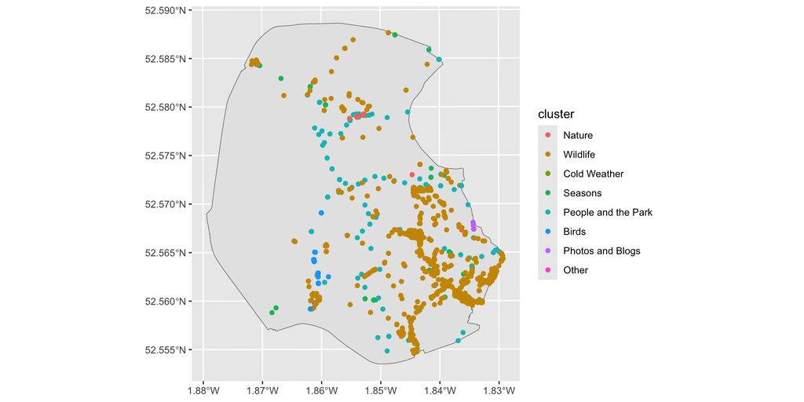

Figure 10: A map showing the locations of photos of Sutton Park (Source: Flickr)

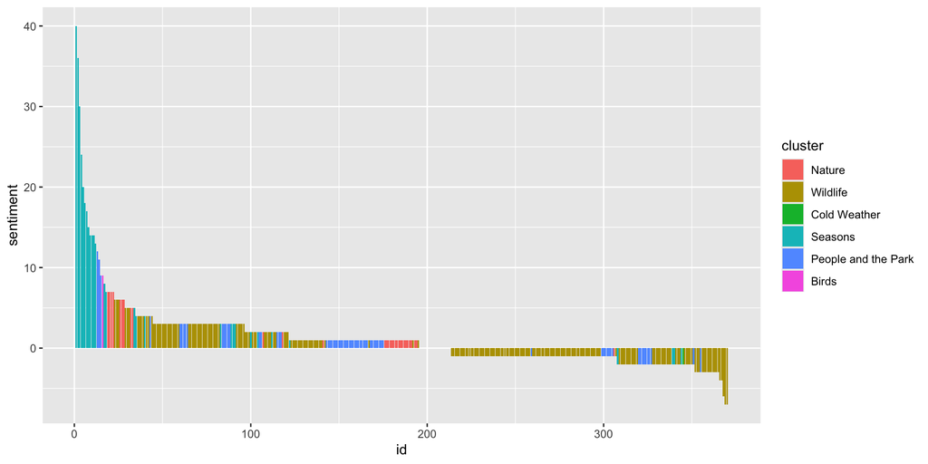

Figure 11: A graph to show sentiment analysis of the photo data of Sutton Park

To further this project, a data source such as Instagram may be useful due its more widespread use, however their API is much more difficult to access. Also of use may be a review platform, such as Google Maps.

## References

Poletti, Flavio, Daniel Herszenhut, Mark Padgham, Tom Buckley, and Danton Noriega-Goodwin. 2026. *Tidytransit: Read, Validate, Analyze, and Map GTFS Feeds*. https://github.com/r-transit/tidytransit.